# Logboek_Janine

2024-05-06

# Logboek kiemgroenten

## Introductie

In dit logboek wordt de voortgang van ons onderzoek bijgehouden.

- Is er al data

# Onderzoeksopzet

### Plan van aanpak

In dit plan van aanpak wordt globaal beschreven hoe dit experiment wordt aangepakt, er wordt verwezen naar protocollen die als bijlage bijgevoegd zijn. Alle documenten die benodigd zijn om dingen in te voeren zijn ook bijgevoegd.

### Experiment

In dit experiment wordt de invloed van verschillende zoutconcentraties op de groei van tuinkers en alfalfa onderzocht. Er is een controlegroep met 0% zout, een groep met 0.03% zout, 0.06% zout en 0.09% zout, er wordt gedemineraliseerd water gebruikt om de zoutconcentratie zo precies mogelijk te kunnen toevoegen. Alle groepen worden in duplo uitgevoerd. De plantjes worden allemaal op 1 locaties gezaaid en geoogst.

### Onderzoeksvraag

Wat is de invloed van verschillende zoutconcentraties op de groei van tuinkers en alfalfa?

### Nulhypothese

Er is geen invloed van verschillende zoutconcentraties op de groei van tuinkers en alfalfa.

### Hypothese

Een oplopende zoutconcentratie hoger dan 0.03% zal een negatieve invloed hebben op de groei van tuinkers en alfalfa.

# Protocollen

# Theoretische achtergrond

De concentratie van opgeloste stoffen in water, welke in de omgeving van een plant is, kan een grote invloed hebben op de plant en de groei van deze plant. In een hypotonische omgeving, de omgeving heeft dan een lagere concentratie opgeloste stoffen, zal het water van de omgeving in de cel van de plant gaan. De cel zal onder meer druk komen te staan, en opzwellen, wanneer deze situatie voor langere tijd niet veranderd zal de cel knappen. In een hypertonische situatie zal water de cellen van de plant verlaten, en zal de plant dus uitdrogen en dood gaan. (Osmosis in Plant Cells - Transport Across Membranes - National 5 Biology Revision - BBC Bitesize, 2023)

Er zijn onderzoeken gedaan naar de invloed van zoutconcentraties op planten, echter is er niks te vinden over de invloed op kiemgroenten.  
Als we kijken naar onderzoeken die al gedaan zijn bij dit onderwerp zien we de volgende concentraties:

- 0%
- 2,922%
- 5,844%
- 8,766%

Uit dit onderzoek is gebleken dat er wel degelijk een significante verandering is op de groei van plantjes, tussen de verschillende zoutconcentraties. Hoe hoger de concentratie hoe meer er een negatieve impact is op de groei van de planten. (Habibi, Armin & Abdoli, Majid. (2013). Influence of salicylic acid pre-treatment on germination, vigor and growth parameters of garden cress (Lepidium sativum) seedlings under water potential loss at salinity stress.)

# Bronnen

Habibi, Armin & Abdoli, Majid. (2013). Influence of salicylic acid pre-treatment on germination, vigor and growth parameters of garden cress (Lepidium sativum) seedlings under water potential loss at salinity stress.

Osmosis in plant cells - Transport across membranes - National 5 Biology Revision - BBC Bitesize. (2023, 17 februari). BBC Bitesize. https://www.bbc.co.uk/bitesize/guides/zqdhjty/revision/6

## Verwerking 7 mei

```r
library(tidyverse)
```

```r
library(ggplot2)
library(ggridges)
library(hrbrthemes)

set.seed(0)
kleur_array <- c("wit", "lichtgroen", "geel", "groen", "donkergroen", "bruin")
cress_data <- data.frame(species = rep(c("cress", "alfalfa"), each=400),
                       N = 1:200,
                       batch_n=rep(c(1, 2), each=200),
                       oplossing=rep(c(0,1,2,3), each=50),
                       cm_groei=c(rnorm(n=50, 5, 1.5),rnorm(n=50, 8,1),rnorm(n=50, 3, 2),rnorm(n=50, 1,0.5), #cress batch 1
                                  rnorm(n=50, 5.5, 1.6),rnorm(n=50, 7.6,1.2),rnorm(n=50, 2.8, 2.1),rnorm(n=50, 1.2,0.6), #cress batch 2
                                  rnorm(n=50, 3, 1),rnorm(n=50, 4,0.8),rnorm(n=50, 2, 0.5),rnorm(n=50, 1,0.2),#alfalfa batch 1
                                  rnorm(n=50, 3.2, 1.1),rnorm(n=50, 3.8,1.1),rnorm(n=50, 2.1, 0.4),rnorm(n=50, 1.2,0.1)), #alfalfa batch 2

                       n_ontkieming=c(rbinom(50, 1, 0.6), rbinom(50, 1, 0.8), rbinom(50, 1, 0.4), rbinom(50, 1, 0.2),
                                      rbinom(50, 1, 0.5), rbinom(50, 1, 0.7), rbinom(50, 1, 0.5), rbinom(50, 1, 0.25),
                                      rbinom(50, 1, 0.7), rbinom(50, 1, 0.9), rbinom(50, 1, 0.3), rbinom(50, 1, 0.3),
                                      rbinom(50, 1, 0.4), rbinom(50, 1, 0.8), rbinom(50, 1, 0.6), rbinom(50, 1, 0.35)),

                       n_blaadjes=c(rnorm(n=50, 3, 1),rnorm(n=50, 4, 1),rnorm(n=50, 2, 1),rnorm(n=50, 1, 0.5), # C batch 1
                                    rnorm(n=50, 3, 1),rnorm(n=50, 4, 1),rnorm(n=50, 2, 1),rnorm(n=50, 1, 0.5), # C batch 2
                                    rnorm(n=50, 3, 1),rnorm(n=50, 4, 1),rnorm(n=50, 2, 1),rnorm(n=50, 1, 0.5), # A batch 1
                                    rnorm(n=50, 3, 1),rnorm(n=50, 4, 1),rnorm(n=50, 2, 1),rnorm(n=50, 1, 0.5)), # A batch 2

                       kleur_blaadjes=rep(c(sample(kleur_array, 800, replace = TRUE)))
                       )
```

# Verwerking 16 mei

Boxplot met oplossing op de x as en cm groei op de y as.Gemaakt door een ingebouwde functie van R. Deze boxplot klopt niet daarom wordt er later gewerkt met de library ggplot2.

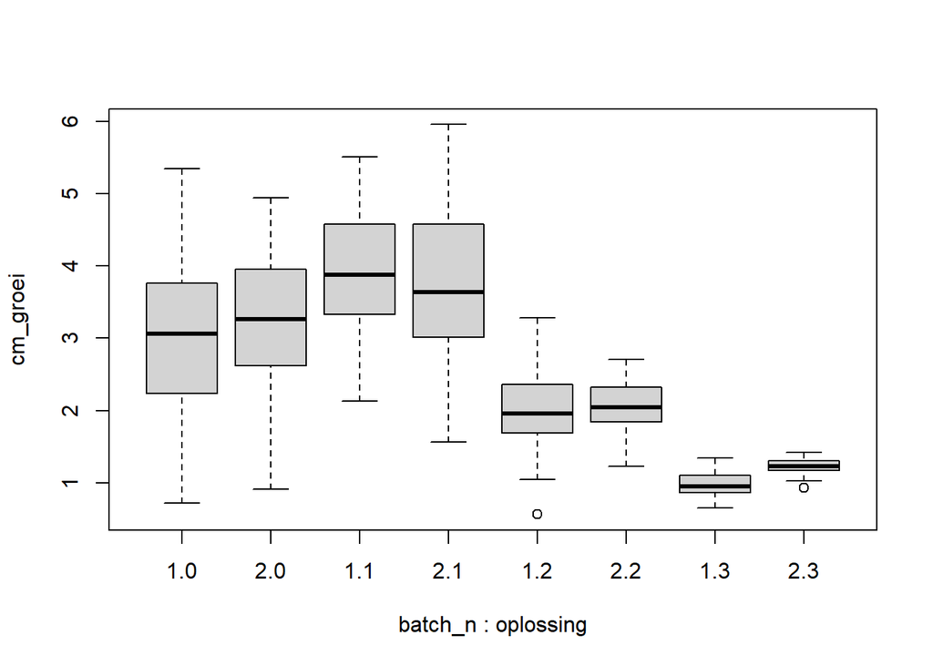

```r
dataset_alfalfa <- cress_data %>%
    filter(species == "alfalfa")
#Door middel van filter kan er een specifieke groep binnen de data geselecteerd worden
boxplot(cm_groei ~ batch_n+oplossing, data=dataset_alfalfa)
```

Welch Two sample T-test. Uitgevoerd voor oefening in R, alleen toepasbaar in de duplo’s in ons onderzoek.

```r
dataset_cress <- cress_data %>%
    filter(species == "cress" & oplossing == 0:1)
t.test(cm_groei ~ oplossing, data=dataset_cress)
```

```
##
##  Welch Two Sample t-test
##
## data:  cm_groei by oplossing
## t = -9.0676, df = 82.161, p-value = 5.196e-14
## alternative hypothesis: true difference in means between group 0 and group 1 is not equal to 0
## 95 percent confidence interval:
##  -3.100835 -1.985082
## sample estimates:
## mean in group 0 mean in group 1
##        5.475919        8.018878
```

Histogram van groei in cm van de tuinkers ter oefening in R. Deze histogram heeft de tuinkers op de x as en groei in cm op de y as. Deze histogram klopt niet helemaal, maar zou wel bruikbaar kunnen zijn voor onze paper.

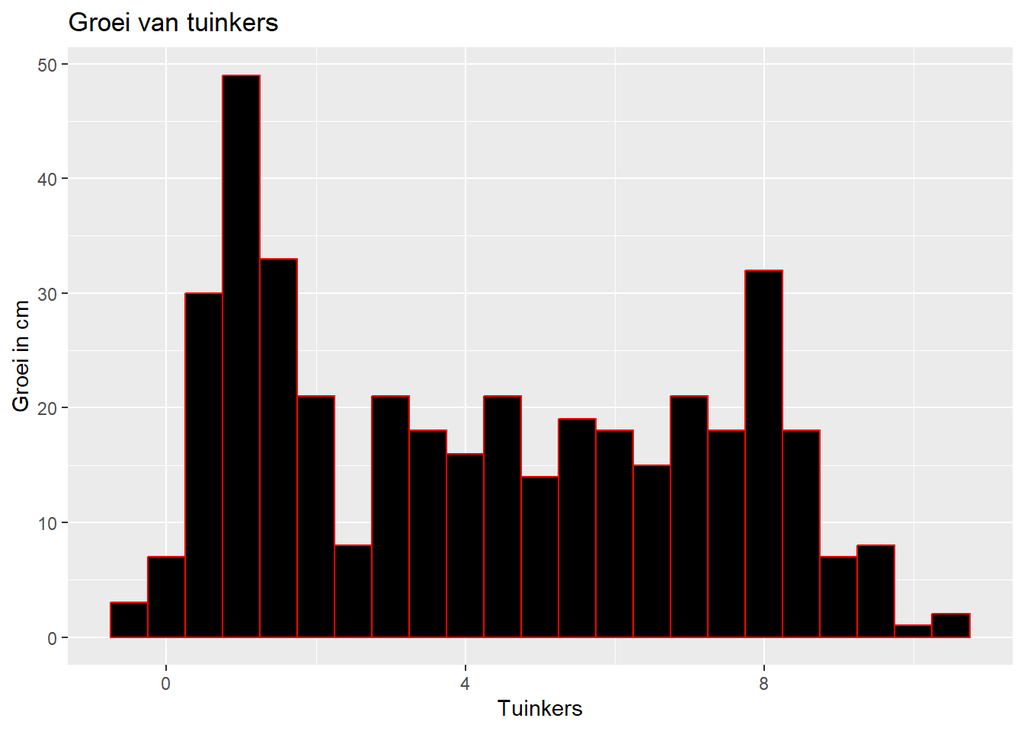

```r
data <- cress_data %>%
    filter(species == "cress")

ggplot(data, aes(x=cm_groei)) +
    geom_histogram( binwidth=0.5, fill="black", color="red") +
    labs(title = "Groei van tuinkers") +
    xlab("Tuinkers") +
    ylab("Groei in cm")
```

# Verwerking 17 mei

In deze barplot staan voor elke soort, batch en oplossing het aantal getelde (gevisualiseerde) data. Deze barplot gaan we zeker gebruiken voor onze paper.

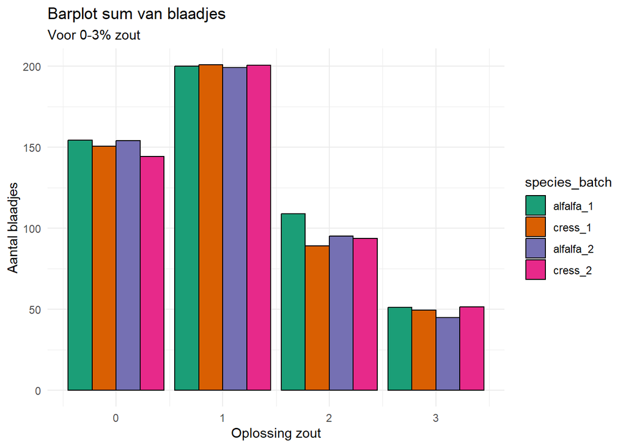

```r
cress_data %>%
    aggregate(n_blaadjes ~ species + batch_n + oplossing, FUN = sum) %>%
    #fct_cross maakt nieuwe kolom en combineert hetgene wat erin staat
    mutate(species_batch = fct_cross(species, as.character(batch_n), sep = "_")) %>%
    #Fill werkt hier als een split functie voor de batches
    ggplot(aes(x=oplossing,y=n_blaadjes, fill=species_batch)) +

    labs(title="Barplot sum van blaadjes",
         subtitle = "Voor 0-3% zout",
         y="Aantal blaadjes",
         x="Oplossing zout") +

    geom_bar(position = "dodge", stat = "sum",
             color="black", size=0.5) +

    #De scalefillbrewer functie is een thema functie
    scale_fill_brewer(palette = "Dark2") +
    theme_minimal()
```

Scatterplot van oplossing op de x as tegenover cm_groei op de y as. Deze plot is niet leesbaar door teveel datapunten op 1 hoop.

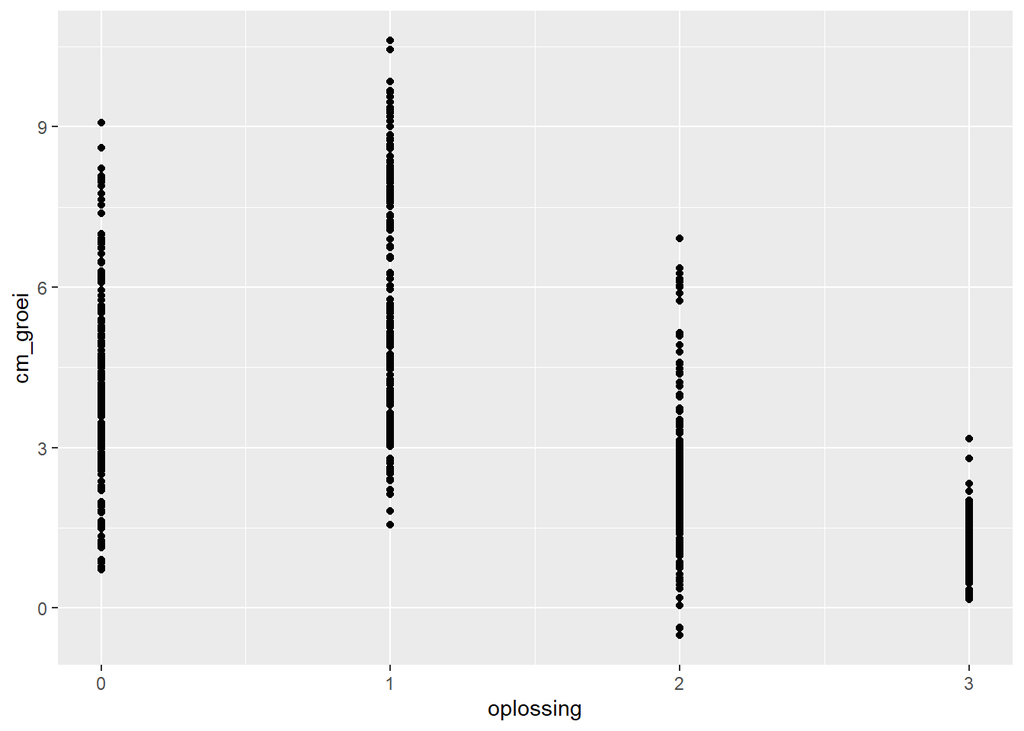

```r
ggplot(cress_data, aes(x=oplossing, y=cm_groei)) +
    geom_point()
```

Boxplot voor aantal blaadjes per batch per oplossing. Deze boxplot is zeer bruikbaar voor onze paper. Er is overzichtelijk te zien voor elke soort en batch de hoeveelheid blaadjes in de verschillende zoutconcentraties.

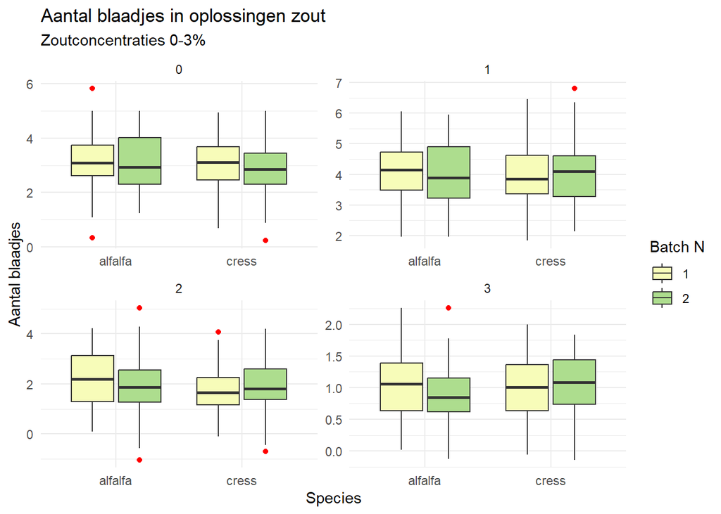

```r
cress_data %>%
    ggplot(aes(x=species, y=n_blaadjes, fill=as.character(batch_n))) +

    labs(title="Aantal blaadjes in oplossingen zout",
         subtitle = "Zoutconcentraties 0-3%",
         x="Species",
         y="Aantal blaadjes",
         fill="Batch N") +

    geom_boxplot(outlier.colour = "red") +
    scale_fill_brewer(palette = "YlGn") +
    theme_minimal() +
    #De facet_wrap zorgt ervoor met de scales functie dat elk plotje eigen waardes op de y-as heeft naar aanleiding van de data die in het plotje zit
    facet_wrap(~ oplossing, scales = "free")
```

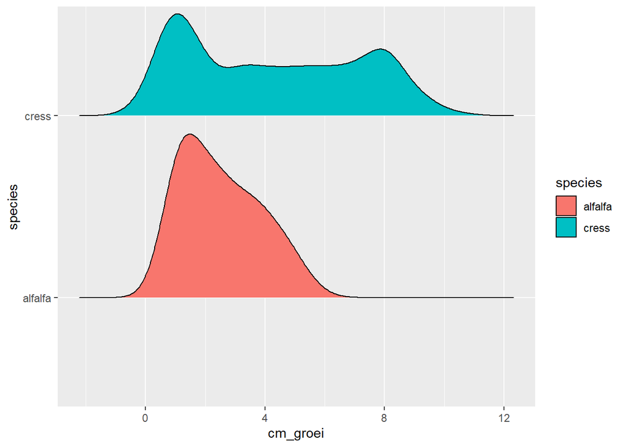

```r
cress_data %>%
    ggplot(aes(x=cm_groei, y=species, fill=species)) +
    geom_density_ridges(scale=0.9)
```

## Verwerking 21 mei

```r
colour_df <- cress_data %>%
    select(species, batch_n, oplossing)
```

### 24-04-2024

Begonnen met protocollen opstellen en uittypen.

### 25-04-2024

Statistiek (les 02) volledig ingevuld om bekend te worden met de statistiekverwerking in R.

### 26-04-2024

De protocollen afgemaakt en laten controleren door Ronald.

### 06-05-2024

Statistiek (les 03) volledig ingevuld om bekend te worden met de statistiekverwerking in R.

### 07-05-2024

Data set is gemaakt door Ramon, behalve de data van de kleur van de blaadjes die heb ik gemaakt op 21 mei. Ik heb de dataset overgenomen om mee te kunnen experimenteren.

### 08-05-2024

Statistiek (les 04) volledig ingevuld om bekend te worden met de statistiekverwerking in R.

### 13-05-204

Onderwerp voor de journalclub presentatie wordt de lollipop graph. Er wordt deze week een presentatie gemaakt en er wordt een markdown document gemaakt waarin verschillende lollipop graph’s uitgebeeld staan als voorbeeld.

### 15-05-2024

Begonnen met onderzoek doen voor de journalclub presentatie. Begonnen met een powerpoint presentatie en begonnen met het visualiseren van verschillende lollipop charts met code in R. Zie hiervoor lollipop_chart.Rmd, staat niet in deze repository.  
Presentatie en code zo goed als afgerond.

### 16-05-2024

Begonnen met verwerken van de testdata in het logboek_Janine. Te vinden onder subtitel, verwerking 16 mei.

Nieuwe zoutoplossingen gemaakt in het lab.

- 0.33 gram voor de 0.03%
- 0.62 gram voor de 0.06%
- 0.90 gram voor de 0.09%
- Gebruikte zout: Sodium chloride, technical. Magazijnnummer Hanze AK4.2-01

### 17-05-2024

Verder met verwerken van testdata in logboek_janine. Te vinden onder subtitel, verwerking 17 mei.  
Half uur gezeten met emile voor extra statistiek uitleg

### 21-05-2024

Dataset aangemaakt voor kleur van blaadjes en hiermee geëxperimenteerd. Te vinden onder subtitel, verwerking 21-05-2024. Logboek aangevuld met theorie, plan van aanpak en protocollen.